# Practical Machine Learning: Prediction Assignment

DirgniF

23 January 2016

# Overview

# Prerequisites

Load the required libraries

```r
suppressWarnings(library(caret))
suppressWarnings(library(rattle))
suppressWarnings(library(e1071))
```

# Loading the Data

```r
download.file("https://d396qusza40orc.cloudfront.net/predmachlearn/pml-training.csv", "pml-training.csv")
download.file("https://d396qusza40orc.cloudfront.net/predmachlearn/pml-testing.csv", "pml-testing.csv")
trainingdata<-read.csv("pml-training.csv",stringsAsFactors = FALSE)
testing<-read.csv("pml-testing.csv",stringsAsFactors = FALSE)
```

# Prepare the Data

Let’s have a look at the training data.

```r
str(trainingdata)
```

```
## 'data.frame':    19622 obs. of  160 variables:
##  $ X                       : int  1 2 3 4 5 6 7 8 9 10 ...
##  $ user_name               : chr  "carlitos" "carlitos" "carlitos" "carlitos" ...
##  $ raw_timestamp_part_1    : int  1323084231 1323084231 1323084231 1323084232 1323084232 1323084232 1323084232 1323084232 1323084232 1323084232 ...
##  $ raw_timestamp_part_2    : int  788290 808298 820366 120339 196328 304277 368296 440390 484323 484434 ...
##  $ cvtd_timestamp          : chr  "05/12/2011 11:23" "05/12/2011 11:23" "05/12/2011 11:23" "05/12/2011 11:23" ...
##  $ new_window              : chr  "no" "no" "no" "no" ...
##  $ num_window              : int  11 11 11 12 12 12 12 12 12 12 ...
##  $ roll_belt               : num  1.41 1.41 1.42 1.48 1.48 1.45 1.42 1.42 1.43 1.45 ...
##  $ pitch_belt              : num  8.07 8.07 8.07 8.05 8.07 8.06 8.09 8.13 8.16 8.17 ...
##  $ yaw_belt                : num  -94.4 -94.4 -94.4 -94.4 -94.4 -94.4 -94.4 -94.4 -94.4 -94.4 ...
##  $ total_accel_belt        : int  3 3 3 3 3 3 3 3 3 3 ...
##  $ kurtosis_roll_belt      : chr  "" "" "" "" ...
##  $ kurtosis_picth_belt     : chr  "" "" "" "" ...
##  $ kurtosis_yaw_belt       : chr  "" "" "" "" ...
```

[output cut: 86 more lines]

So we have 160 columns, but it seems there are a lot of columns that mainly hold “” or NAs. We define a function “percInvalid” which calculates the percentage of such invalid values in a vector. We apply this function to the dataframe columns using apply. We decide to only retain features that have less than 10% of invalid entries.

```r
percInvalid<-function(x){(sum(is.na(x))+sum(x=="",na.rm=TRUE))/length(x)}
FeaturePercInvalid<-apply(trainingdata,2, percInvalid)
retainFeature<-FeaturePercInvalid<.1
sum(retainFeature)
```

```
## [1] 60
```

We see that we are now left with 60 features only. Furthermore, a good predictor should not rely on the subject that did the test, nor on the window or the timestamp. Finally, the rownumber, X, should not be considered a feature.

```r
retainFeature["user_name"]<-FALSE
retainFeature[grepl("window",names(trainingdata))]<-FALSE
retainFeature[grepl("time",names(trainingdata))]<-FALSE
retainFeature["X"]<-FALSE
sum(retainFeature)
```

```
## [1] 53
```

With this, we are down to 53 features.

We retain only the selected features and observe that with this manipulation, we have effectively removed all NAs from the data frame.

```r
trainingdata<-trainingdata[,retainFeature]
nrow(trainingdata[!complete.cases(trainingdata),])
```

```
## [1] 0
```

Finally, we turn the classe variable into a factor, and check that we have sufficient records for each value of class.

```r
trainingdata$classe<-as.factor(trainingdata$classe)
round(prop.table(table(trainingdata$classe)),2)
```

```
##
##    A    B    C    D    E
## 0.28 0.19 0.17 0.16 0.18
```

# Partioning the Data

The dataframe trainingdata has 19622 observations. This is plenty, so we can partition this set further in a training set that holds 75% of the observations and a validation set that holds the reminder. This validation set will be used to estimate the out-of-sample error rate.

```r
set.seed(314)
inTrain = createDataPartition(trainingdata$classe, p = 3/4)[[1]]
training = trainingdata[ inTrain,]
validation = trainingdata[-inTrain,]
```

# Attempt 1: Classification and Regression Tree

We use regression trees, and the train function uses repeated cross validation to determine the best model. We also set the tuneLenth to 10 to ensure sufficient granularity in the tuning parameter grid. (The default of 3 is known to be a bit coarse) We plot the resulting decision tree.

```r
modelFit1<-train(classe ~ ., data = training, method = "rpart",tuneLength = 10,trControl=trainControl(method = "repeatedcv"))
```

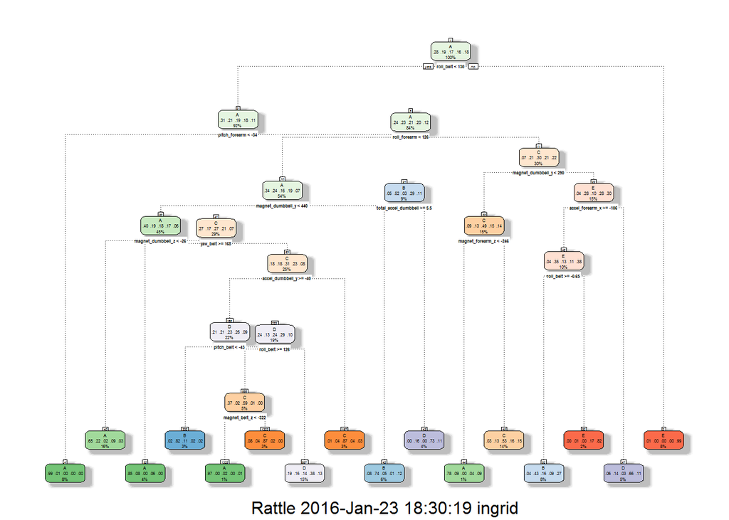

```r
fancyRpartPlot(modelFit1$finalModel)
```

We now use the model to predict the values in the validation set, and print the confusion matrix.

```r
validation1<-predict(modelFit1,validation,type="raw")
confusionMatrix(validation1,validation$classe)
```

```
## Confusion Matrix and Statistics
##
##           Reference
## Prediction    A    B    C    D    E
##          A 1183  189   17   76   34
##          B   28  525   77   50  146
##          C   36   81  663  109  112
##          D  146  151   98  549  134
##          E    2    3    0   20  475
##
## Overall Statistics
##
##                Accuracy : 0.6923
##                  95% CI : (0.6792, 0.7052)
##     No Information Rate : 0.2845
##     P-Value [Acc > NIR] : < 2.2e-16
##
##                   Kappa : 0.6105
##  Mcnemar's Test P-Value : < 2.2e-16
##
## Statistics by Class:
##
##                      Class: A Class: B Class: C Class: D Class: E
## Sensitivity            0.8480   0.5532   0.7754   0.6828  0.52719
## Specificity            0.9099   0.9239   0.9165   0.8710  0.99375
## Pos Pred Value         0.7892   0.6356   0.6623   0.5093  0.95000
## Neg Pred Value         0.9377   0.8960   0.9508   0.9334  0.90327
## Prevalence             0.2845   0.1935   0.1743   0.1639  0.18373
## Detection Rate         0.2412   0.1071   0.1352   0.1119  0.09686
## Detection Prevalence   0.3057   0.1684   0.2041   0.2198  0.10196
## Balanced Accuracy      0.8790   0.7386   0.8460   0.7769  0.76047
```

An accuracy of 69, with corresponds to the out-of-error sample rate is not bad, but it may not be enought to get a 80% score on the test, so let’s try another method.

# Attempt 2: Support Vector Machine

We build the model, using default settings, and apply it again to the validation set.

```r
modelFit2<-svm(classe ~ ., data = training)
validation2<-predict(modelFit2,validation,type="raw")
confusionMatrix(validation2,validation$classe)
```

```
## Confusion Matrix and Statistics
##
##           Reference
## Prediction    A    B    C    D    E
##          A 1388   89    2    3    0
##          B    4  840   20    0    4
##          C    2   19  829   82   14
##          D    0    1    4  718   17
##          E    1    0    0    1  866
##
## Overall Statistics
##
##                Accuracy : 0.9464
##                  95% CI : (0.9397, 0.9525)
##     No Information Rate : 0.2845
##     P-Value [Acc > NIR] : < 2.2e-16
##
##                   Kappa : 0.932
##  Mcnemar's Test P-Value : < 2.2e-16
##
## Statistics by Class:
##
##                      Class: A Class: B Class: C Class: D Class: E
## Sensitivity            0.9950   0.8851   0.9696   0.8930   0.9612
## Specificity            0.9732   0.9929   0.9711   0.9946   0.9995
## Pos Pred Value         0.9366   0.9677   0.8763   0.9703   0.9977
## Neg Pred Value         0.9980   0.9730   0.9934   0.9793   0.9913
## Prevalence             0.2845   0.1935   0.1743   0.1639   0.1837
## Detection Rate         0.2830   0.1713   0.1690   0.1464   0.1766
## Detection Prevalence   0.3022   0.1770   0.1929   0.1509   0.1770
## Balanced Accuracy      0.9841   0.9390   0.9703   0.9438   0.9803
```

```r
test2<-predict(modelFit2,testing,type="raw")
```